# Econ HW2

Kristin Gill and Alyssa Kibbe

4/14/2021

```r
# read in the data
water_data <- read_csv(here("data", "HW2_Water.csv")) %>%
  clean_names()
```

##### TO: Baja California Sur and Baja California Water Officials

##### FROM: Alyssa Kibbe and Kristin Gill, Water Experts

## 1.

### Agriculture

P = 1.9 + 0.51(abatement)

### Meat

P = 9.5 + 0.38(abatement)

### Industrial

P = -27 + 1.1(abatement)

### Urban

P = -14 + 0.6(abatement)

### Combined Marginal Cost per Industry

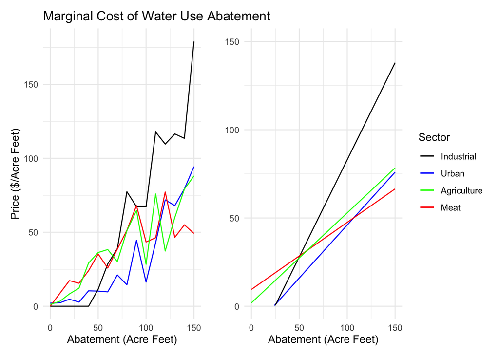

**Figure 1:** The marginal cost of water use abatement in Baja California and Baja California Sur for the sectors Agriculture, Industrial, Meat, and Urban. Water quantity is measured in Acre Feet and price is Dollars per Acre Feet. The graph on the left is the original marginal cost data and the graph on the right shows the estimated marginal cost curves using linear regression.

```r
#combined graphs
og_data <- ggplot() +
  geom_line(data = water_data, aes(x = reduced_water_use_abatement,y = mc_urban, color = "blue"), show.legend = FALSE) +
  geom_line(data = water_data, aes(x = reduced_water_use_abatement, y = mc_industrial, color = "black"), show.legend = FALSE) +
  geom_line(data = water_data, aes(x = reduced_water_use_abatement, y=mc_meat, color = "red"), show.legend = FALSE) +
  geom_line(data = water_data, aes(x = reduced_water_use_abatement, y=mc_agriculture, color = "green"), show.legend = FALSE) +
  labs(x = "Abatement (Acre Feet)",
       y = "Price ($/Acre Feet)",
       title = "Marginal Cost of Water Use Abatement",
       color = "Sector") +
  theme_minimal() +
  scale_x_continuous(limit = c(0,150)) +
  scale_color_manual(labels = c("Industrial", "Urban", "Agriculture", "Meat"), values = c("black", "blue", "green", "red"))

# is this what they are asking for?
ag_df <- data.frame(abatement = seq.int(from = 0, to = 350)) %>%
  mutate(price = 1.9 + (0.51*abatement))

meat_df <- data.frame(abatement = seq.int(from = 0, to = 350)) %>%
  mutate(price = 9.5 + (0.38*abatement))

industrial_df <- data.frame(abatement = seq.int(from = 0, to = 350)) %>%
  mutate(price = -27 + (1.1*abatement))

urban_df <- data.frame(abatement = seq.int(from = 0, to = 350)) %>%
  mutate(price = -14 + (0.6*abatement))

reg_data <- ggplot() +
  geom_line(data = urban_df, aes(x = abatement, y = price, color = "blue")) +
  geom_line(data = industrial_df, aes(x = abatement, y = price, color = "black")) +
  geom_line(data = meat_df, aes(x = abatement, y = price, color = "red")) +
  geom_line(data = ag_df, aes(x = abatement, y = price, color = "green")) +
  labs(x = "Abatement (Acre Feet)",
       y = " ",
       color = "Sector") +
  theme_minimal() +
  scale_x_continuous(limit = c(0,150)) +
  scale_y_continuous(limit = c(0,150)) +
  scale_color_manual(labels = c("Industrial", "Urban", "Agriculture", "Meat"), values = c("black", "blue", "green", "red"))

# put them together
graph_compound <- (og_data|reg_data) & plot_layout(guides = "collect")

graph_compound
```

## 2.

### Agriculture

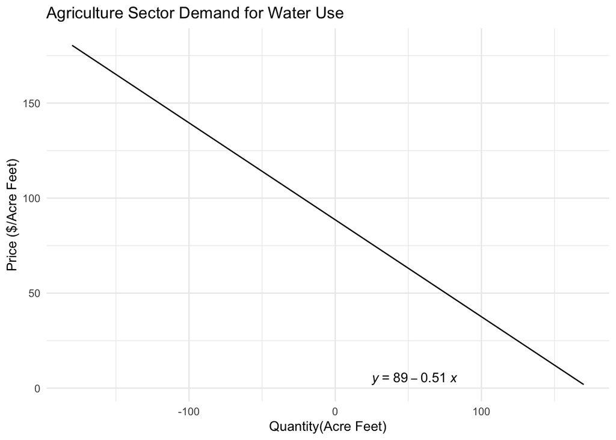

```r
ag_df <- data.frame(abatement = seq.int(from = 0, to = 350)) %>%
  mutate(price = 1.9 + (0.51*abatement)) %>%
  mutate(quantity = 170 - abatement)

ggplot(data = ag_df, aes(x = quantity,
                         y = price)) +
  geom_line() +
  theme_minimal() +
  labs(x = "Quantity(Acre Feet)",
       y = "Price ($/Acre Feet)",
       title = "Agriculture Sector Demand for Water Use") +
  ggpubr::stat_regline_equation(label.x = 25, label.y = 5)
```

### Meat

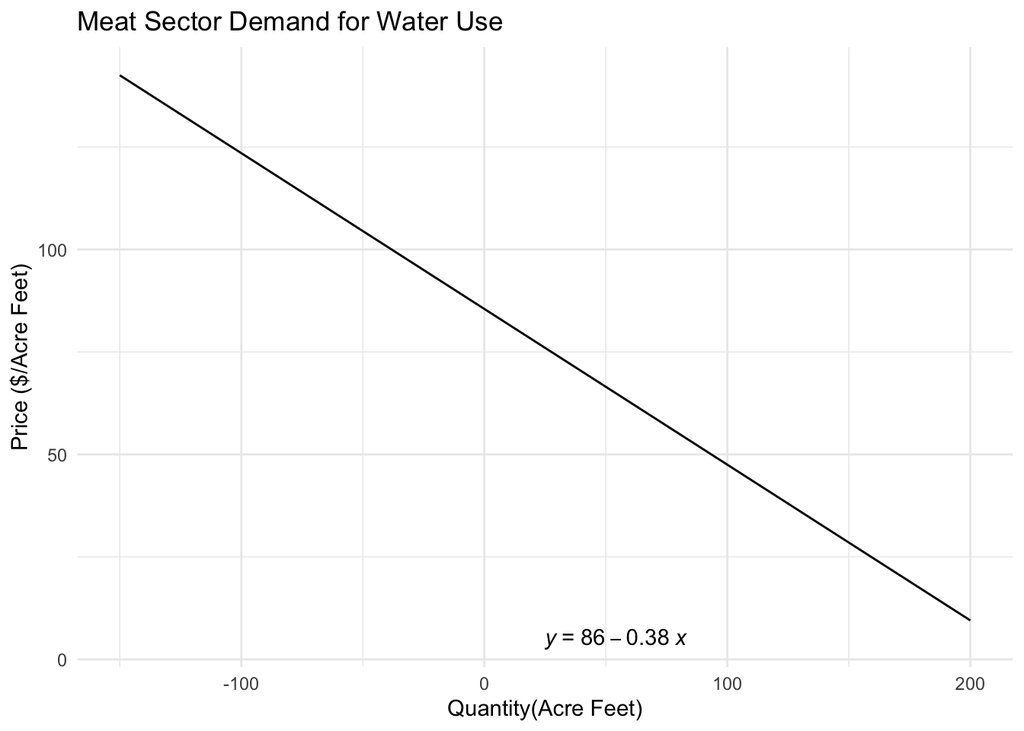

```r
meat_df <- data.frame(abatement = seq.int(from = 0, to = 350)) %>%
  mutate(price = 9.5 + (0.38*abatement)) %>%
  mutate(quantity = 200 - abatement)

ggplot(data = meat_df, aes(x = quantity,
                         y = price)) +
  geom_line() +
  theme_minimal() +
  labs(x = "Quantity(Acre Feet)",
       y = "Price ($/Acre Feet)",
       title = "Meat Sector Demand for Water Use") +
  ggpubr::stat_regline_equation(label.x = 25, label.y = 5)
```

### Industrial

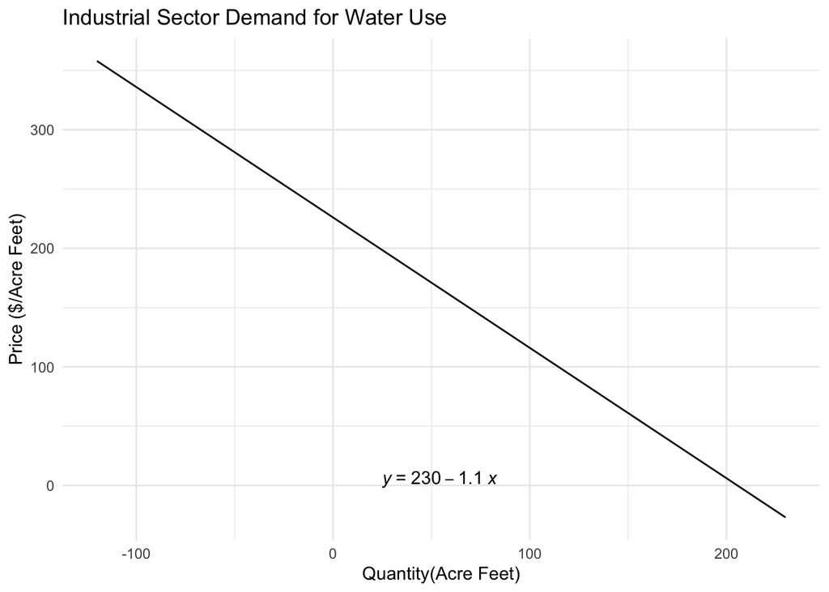

```r
industrial_df <- data.frame(abatement = seq.int(from = 0, to = 350)) %>%
  mutate(price = -27 + (1.1*abatement)) %>%
  mutate(quantity = 230 - abatement)

ggplot(data = industrial_df, aes(x = quantity,
                                 y = price)) +
  geom_line() +
  theme_minimal() +
  labs(x = "Quantity(Acre Feet)",
       y = "Price ($/Acre Feet)",
       title = "Industrial Sector Demand for Water Use") +
  ggpubr::stat_regline_equation(label.x = 25, label.y = 5)
```

### Urban

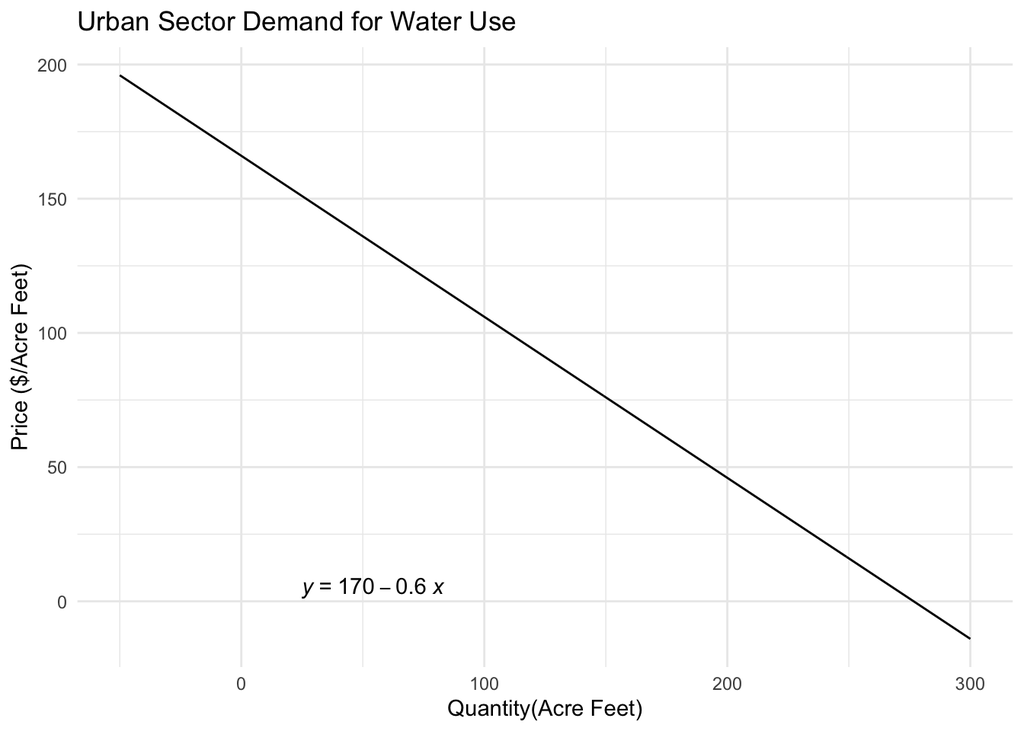

```r
urban_df <- data.frame(abatement = seq.int(from = 0, to = 350)) %>%
  mutate(price = -14 + (0.6*abatement)) %>%
  mutate(quantity = 300 - abatement)

ggplot(data = urban_df, aes(x = quantity,
                         y = price)) +
  geom_line() +
  theme_minimal() +
  labs(x = "Quantity(Acre Feet)",
       y = "Price ($/Acre Feet)",
       title = "Urban Sector Demand for Water Use") +
  ggpubr::stat_regline_equation(label.x = 25, label.y = 5)
```

The industrial sector is willing to pay the most ($230) for the first acre foot of water.

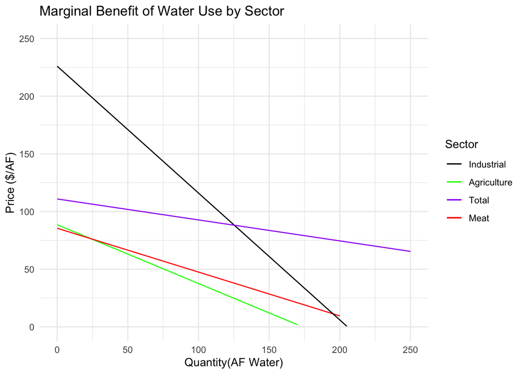

```r
# all the BC demand curves together
baja_tot_df <- data.frame(quantity = seq.int(from = 0, to = 600)) %>%
  mutate(price = (quantity - 609.92)/(-5.50)) %>%
  mutate(abatement = 600 - quantity)

ggplot() +
  geom_line(data = ag_df, aes(x = quantity,
                       y = price,
                       color = "green")) +
  geom_line(data = meat_df, aes(x = quantity,
                         y = price,
                         color = "red")) +
  geom_line(data = industrial_df, aes(x = quantity,
                               y = price,
                               color = "black")) +
  geom_line(data = baja_tot_df, aes(x = quantity,
                                    y = price,
                                    color = "purple")) +
  theme_minimal() +
  scale_x_continuous(limits = c(0,250)) +
  scale_y_continuous(limits = c(0,250)) +
  labs(x = "Quantity(AF Water)",
       y = "Price ($/AF)",
       title = "Marginal Benefit of Water Use by Sector",
       color = "Sector") +
  scale_color_manual(labels = c("Industrial", "Agriculture", "Total", "Meat"), values = c("black", "green", "purple", "red"))
```

## 3. Baja California: Agriculture, Meat, and Industrial

### A. Cap on water use (cut 100AF/sector)

#### (1) the total cost of meeting the target in Baja California

$$\int_0^{300} 1.8 + 0.18A$$

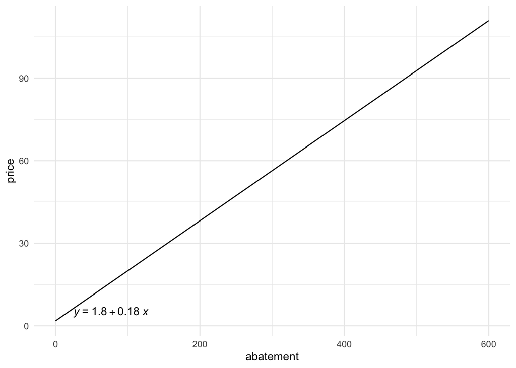

```r
# demand aggregate for Baja California = demand agriculture + demand industrial + demand meat

# demand agriculture: P = 89 - 0.51 Q --> Q = (P-89)/(-0.51)
# demand industrial: P = 230 - 1.1 Q --> Q = (P - 230)/(-1.1)
# demand meat: P = 86 - 0.38 Q --> Q = (P - 86)/(-0.38)

# demand aggregate: P = (Q - 609.92)/(-5.50)

baja_tot_df <- data.frame(quantity = seq.int(from = 0, to = 600)) %>%
  mutate(price = (quantity - 609.92)/(-5.50)) %>%
  mutate(abatement = 600 - quantity)

ggplot(data = baja_tot_df, aes(x = abatement,
                               y = price)) +
  geom_line() +
  theme_minimal() +
  ggpubr::stat_regline_equation(label.x = 25, label.y = 5)
```

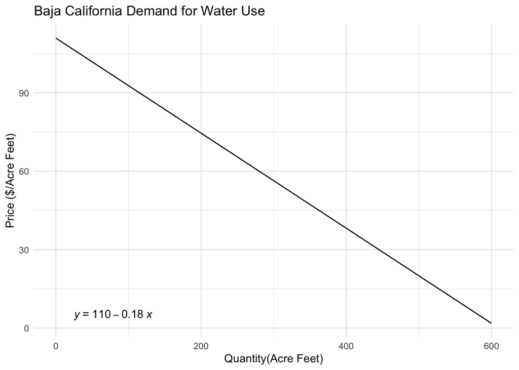

```r
ggplot(data = baja_tot_df, aes(x = quantity,
                               y = price)) +
  geom_line() +
  theme_minimal() +
  labs(x = "Quantity(Acre Feet)",
       y = "Price ($/Acre Feet)",
       title = "Baja California Demand for Water Use") +
  ggpubr::stat_regline_equation(label.x = 25, label.y = 5)
```

```r
p_tot <- function(A) {1.8 + (0.18*A)}
integrate(p_tot, lower = 0, upper = 300)
```

```
## 8640 with absolute error < 9.6e-11
```

#### (2) the total cost (or benefit) to each sector

Agriculture Sector Cost

$$\int_0^{100} 1.9 + 0.51A$$

```r
p_ag <- function(A) {1.9 + (0.51*A)}
integrate(p_ag, lower = 0, upper = 100)
```

```
## 2740 with absolute error < 3e-11
```

Meat Sector Cost

$$\int_0^{100} 9.5 + 0.38A$$

```r
p_meat <- function(A) {9.5 + (0.38*A)}
integrate(p_meat, lower = 0, upper = 100)
```

```
## 2850 with absolute error < 3.2e-11
```

Industrial Sector Cost

$$\int_0^{100} -27 + 1.1A$$

```r
p_industrial <- function(A) {-27 + (1.1*A)}
integrate(p_industrial, lower = 0, upper = 100)
```

```
## 2800 with absolute error < 3.8e-11
```

#### (3) the tax revenue generated

There is no tax revenue generated when a cap is put on pollution because no taxes have been implemented.

### B. Tax on water use

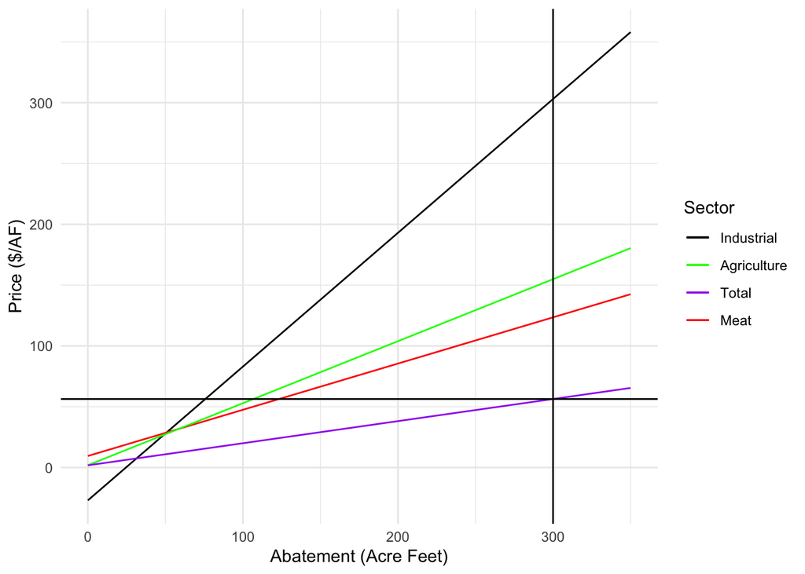

```r
# finding the tax
ggplot() +
  geom_line(data = industrial_df, aes(x = abatement, y = price, color = "black")) +
  geom_line(data = meat_df, aes(x = abatement, y = price, color = "red")) +
  geom_line(data = ag_df, aes(x = abatement, y = price, color = "green")) +
  geom_line(data = baja_tot_df, aes(x = abatement,
                                    y = price,
                                    color = "purple")) +
  geom_vline(xintercept = 300) +
  geom_hline(yintercept = 56.34909) + # the price when total Baja California abatement is 300
  labs(x = "Abatement (Acre Feet)",
       y = "Price ($/AF)",
       color = "Sector") +
  theme_minimal() +
  scale_x_continuous(limits = c(0,350)) +
  scale_color_manual(labels = c("Industrial", "Agriculture", "Total", "Meat"), values = c("black", "green", "purple", "red"))
```

```r
# equation for aggregate MC: P = 1.8 + 0.18(abatement); to cut water supply in half, abatement = 300
tax = 1.8 + (0.18*300)
tax
```

```
## [1] 55.8
```

#### (1) the total cost of meeting the target in Baja California

$$\int_0^{300} 1.8 + 0.18A$$

```r
p_tot <- function(A) {1.8 + (0.18*A)}
integrate(p_tot, lower = 0, upper = 300)
```

```
## 8640 with absolute error < 9.6e-11
```

#### (2) the total cost (or benefit) to each sector

Agriculture Sector Cost

$$\int_0^{105} 1.9 + 0.51A$$

```r
p_ag_tax <- function(A) {1.9 + (0.51*A)}
integrate(p_ag, lower = 0, upper = 105)
```

```
## 3010.875 with absolute error < 3.3e-11
```

Meat Sector cost
$$\int_0^{121} 9.5 + 0.38A$$

```r
p_meat <- function(A) {9.5 + (0.38*A)}
integrate(p_meat, lower = 0, upper = 121)
```

```
## 3931.29 with absolute error < 4.4e-11
```

Industrial Sector Cost
$$\int_0^{75} -27 + 1.1A$$

```r
p_industrial <- function(A) {-27 + (1.1*A)}
integrate(p_industrial, lower = 0, upper = 75)
```

```
## 1068.75 with absolute error < 1.9e-11
```

#### (3) the tax revenue generated

```r
tax_revenue = tax*300
tax_revenue
```

```
## [1] 16740
```

### C. Water Cap and Trade

Permits: AG: 170 - 100 = 70 Meat: 200 - 100 = 100 Industrial: 230 - 100 = 130

Price when Baja CA abatement is 300 → $55.80 (equivalent to the tax in part b) AG abatement: ~106 Meat abatement: ~122 Industrial abatement: ~75

Would they buy or sell? Permit - abatement < 0 → buying; permit - abatement > 0 → sell AG: 70 - 106 = -36 BUY Meat: 100 - 122 = -22 BUY Industrial: 130 - 75 = 55 SELL

#### (1) the total cost of meeting the target in Baja California

$$\int_0^{300} 1.8 + 0.18A$$

```r
p_tot <- function(A) {1.8 + (0.18*A)}
integrate(p_tot, lower = 0, upper = 300)
```

```
## 8640 with absolute error < 9.6e-11
```

#### (2) the total cost (or benefit) to each sector

Agriculture Sector Cost

```r
ag_cost = tax*35
ag_cost
```

```
## [1] 1953
```

Meat Sector Cost

```r
meat_cost = tax*21
meat_cost
```

```
## [1] 1171.8
```

Industrial Sector Benefit

```r
industrial_benefit = tax*55
industrial_benefit
```

```
## [1] 3069
```

#### (3) the tax revenue generated

NONE

## 4. Baja California Sur enters Cap and Trade

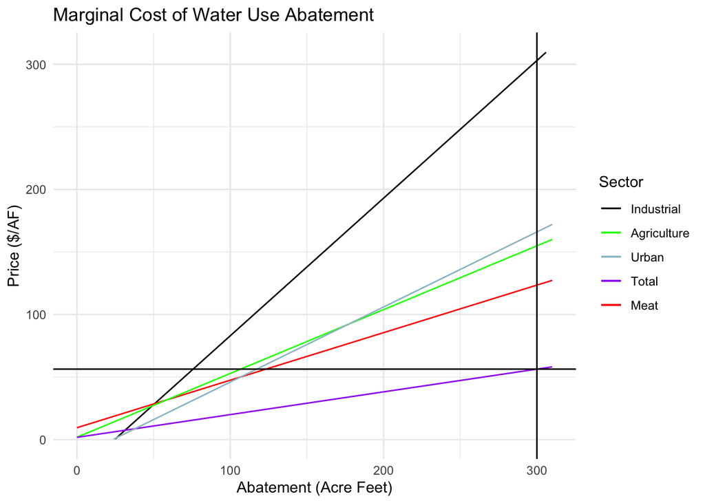

```r
ggplot() +
  geom_line(data = industrial_df, aes(x = abatement, y = price, color = "black")) +
  geom_line(data = meat_df, aes(x = abatement, y = price, color = "red")) +
  geom_line(data = ag_df, aes(x = abatement, y = price, color = "green")) +
  geom_line(data = baja_tot_df, aes(x = abatement,
                                    y = price,
                                    color = "purple")) +
  geom_line(data = urban_df, aes(x = abatement,
                                 y = price,
                                 color = "lightblue")) +
  geom_vline(xintercept = 300) +
  geom_hline(yintercept = 56.34909) + # the price when total Baja California abatement is 300
  labs(x = "Abatement (Acre Feet)",
       y = "Price ($/AF)",
       color = "Sector",
       title = "Marginal Cost of Water Use Abatement") +
  theme_minimal() +
  scale_x_continuous(limits = c(0,310)) +
  scale_y_continuous(limits = c(0,310)) +
  scale_color_manual(labels = c("Industrial", "Agriculture", "Urban", "Total", "Meat"), values = c("black", "green", "lightblue3", "purple", "red"))
```

Baja California Sur (BCS) cap at 300AF means that the urban sector only has to cap its water use at 300AF. At the permit trading price of $55.80, BCS would abate 116AF of water. The difference between the permitted amount and abatement is 184AF, so BCS would have 184AF of water to sell in the market.

## 5. Co-Benefits of Reduced Water Use